# Iyer_2024_GSE263238_bulkRNA-seq_analysis

Author

Pakorn Sagulkoo

In this code, we will analyse mouse bulk RNA-seq from [Iyer et al. (2024)](https://pubmed.ncbi.nlm.nih.gov/39083585/). This study employed a mouse experimental model in which a CLL- and RT-like condition was induced using *CD19<sup>cre/+</sup> Mdr<sup>fl/+</sup> Sf3b1<sup>fl/+</sup> Cas9<sup>fl/+</sup>* mice engrafted with LSK cells transduced with sgRNA-expressing lentivirus. After we performed Salmon converting FASTQ files to pseudocount data in each sample, we will convert them to a count matrix before we use the matrix for DESeq2 for further gene expression analysis.

## Import the relevant packages and set working path directory

```r
# Import the relavant packages
library(tximport)
library(ensembldb)
library(biomaRt)
library(dplyr)
library(tibble)
library(stringr)
library(ggplot2)
library(ggrepel)
library(DESeq2)
```

```r
# Check root path
here::here()
```

```
[1] "/mnt/hp-storage/users/pakorns"
```

## Define paths

```r
# Define paths to load and save files
path_to_samples <- here::here("RNAseq/Iyer_2024_GSE263238")
path_to_sample_metadata <- here::here("RNAseq/systematic_review/2-Iyer_2024_GSE263238/sample_metadata.csv")
path_to_ref_transcriptome <- "/home/pakorns/hc-storage/fastq_files/RNAseq/transcriptome_ref"
path_to_save_txi <- here::here("RNAseq/systematic_review/2-Iyer_2024_GSE263238/count_matrices/Iyer_txi.rds")
path_to_save_RT_vs_CRTL_dea <- here::here("RNAseq/systematic_review/2-Iyer_2024_GSE263238/expression_data/Iyer_RT_vs_CRTL_dea.rds")
path_to_save_CLL_vs_CRTL_dea <- here::here("RNAseq/systematic_review/2-Iyer_2024_GSE263238/expression_data/Iyer_CLL_vs_CRTL_dea.rds")
path_to_save_RT_vs_CLL_dea <- here::here("RNAseq/systematic_review/2-Iyer_2024_GSE263238/expression_data/Iyer_RT_vs_CLL_dea.rds")
path_to_save_hm_gsea <- here::here("RNAseq/systematic_review/2-Iyer_2024_GSE263238/enrichment_data/Iyer_hm_gsea.rds")
path_to_save_go_gsea <- here::here("RNAseq/systematic_review/2-Iyer_2024_GSE263238/enrichment_data/Iyer_go_gsea.rds")
```

## Load data and functions

```r
# Source functions
source(here::here("bin/utils.R"))
```

```r
# Load sample metadata
sample_metadata <- read.csv(path_to_sample_metadata)
DT::datatable(sample_metadata, options = list(scrollX = TRUE))
```

|  | SRA_RUN | GSM_ID | tissue | condition |
| --- | --- | --- | --- | --- |
| 1 | SRR28560276 | GSM8188302 | Spleen | CTRL |
| 2 | SRR28560277 | GSM8188301 | Spleen | CTRL |
| 3 | SRR28560278 | GSM8188300 | Spleen | CTRL |
| 4 | SRR28560279 | GSM8188299 | Spleen | CTRL |
| 5 | SRR28560280 | GSM8188298 | Spleen | CTRL_no_sgRNA |
| 6 | SRR28560281 | GSM8188297 | Spleen | CLL |
| 7 | SRR28560282 | GSM8188296 | Spleen | CLL |
| 8 | SRR28560283 | GSM8188295 | Spleen | RT |
| 9 | SRR28560284 | GSM8188294 | Spleen | RT |

As the original study did not analyse in control with no sgRNA, we will remove it from the further analysis.

```r
# Select samples without control with no sgRNA
metadata_no_sgRNA <- sample_metadata[sample_metadata$condition != "CTRL_no_sgRNA", ]
```

```r
# Create a vector collecting Salmon quant.sf path in each sample
path_to_download <- str_c(path_to_samples, "/", metadata_no_sgRNA$SRA_RUN, "/quant.sf")
names(path_to_download) <- metadata_no_sgRNA$SRA_RUN
path_to_download
```

```
                                                                    SRR28560276
"/mnt/hp-storage/users/pakorns/RNAseq/Iyer_2024_GSE263238/SRR28560276/quant.sf"
                                                                    SRR28560277
"/mnt/hp-storage/users/pakorns/RNAseq/Iyer_2024_GSE263238/SRR28560277/quant.sf"
                                                                    SRR28560278
"/mnt/hp-storage/users/pakorns/RNAseq/Iyer_2024_GSE263238/SRR28560278/quant.sf"
                                                                    SRR28560279
"/mnt/hp-storage/users/pakorns/RNAseq/Iyer_2024_GSE263238/SRR28560279/quant.sf"
                                                                    SRR28560281
"/mnt/hp-storage/users/pakorns/RNAseq/Iyer_2024_GSE263238/SRR28560281/quant.sf"
                                                                    SRR28560282
"/mnt/hp-storage/users/pakorns/RNAseq/Iyer_2024_GSE263238/SRR28560282/quant.sf"
                                                                    SRR28560283
"/mnt/hp-storage/users/pakorns/RNAseq/Iyer_2024_GSE263238/SRR28560283/quant.sf"
                                                                    SRR28560284
"/mnt/hp-storage/users/pakorns/RNAseq/Iyer_2024_GSE263238/SRR28560284/quant.sf"
```

## Convert salmon pseudocounts to an expression matrix

```r
# Load the ensembl mm39 gtf file
path_to_mm39_transcriptome <- str_c(path_to_ref_transcriptome, "/Mus_musculus.GRCm39.115.gtf.gz")
edb <- ensDbFromGtf(path_to_mm39_transcriptome) # Return edb = "./Mus_musculus.GRCm39.115.sqlite"
```

```r
# Make the transcript-to-gene map (tx2gene)
edb <- "./Mus_musculus.GRCm39.115.sqlite"
edb_obj <- EnsDb(edb)
tx2gene <- transcripts(edb_obj,
                       columns = c("tx_id","gene_id","gene_name"),
                       return.type="DataFrame")

# convert to a plain data.frame for tximport
tx2gene <- as.data.frame(tx2gene)
head(tx2gene)
```

```
               tx_id            gene_id gene_name
1 ENSMUST00000000001 ENSMUSG00000000001     Gnai3
2 ENSMUST00000000003 ENSMUSG00000000003      Pbsn
3 ENSMUST00000000010 ENSMUSG00000020875     Hoxb9
4 ENSMUST00000000028 ENSMUSG00000000028     Cdc45
5 ENSMUST00000000033 ENSMUSG00000048583      Igf2
6 ENSMUST00000000049 ENSMUSG00000000049      Apoh
```

```r
# Load pseudocount files
txi <- tximport(path_to_download,
                type = "salmon",
                tx2gene = tx2gene,
                ignoreTxVersion = TRUE
               )

# This gives you txi$counts, txi$abundance (TPM), txi$length
head(txi$counts)
```

```
                   SRR28560276 SRR28560277 SRR28560278 SRR28560279 SRR28560281
ENSMUSG00000000001     662.714    1986.391        1321         508        3907
ENSMUSG00000000003       0.000       0.000           0           0           0
ENSMUSG00000000028     127.000     391.108         258         163           0
ENSMUSG00000000037       1.000       1.000           3           0           0
ENSMUSG00000000049       1.000       2.000           1           0           0
ENSMUSG00000000056     176.000     570.918         575         243           0
                   SRR28560282 SRR28560283 SRR28560284
ENSMUSG00000000001    1700.995        1179        2923
ENSMUSG00000000003       0.000           0           0
ENSMUSG00000000028     683.999         887        2270
ENSMUSG00000000037      26.000           0           0
ENSMUSG00000000049      18.000           1           2
ENSMUSG00000000056     488.000         453        1091
```

```r
# Save the expression file
saveRDS(txi, path_to_save_txi)
```

## Transcriptomics analysis using DESeq2

```r
# Import the relevant package
library(DESeq2)
library(sva)
library(limma)
```

### Create a DESeq2 object

```r
# Create metadata for DESeq2 object
colData <- metadata_no_sgRNA[, c("SRA_RUN", "condition")] %>%
  rename(samples = "SRA_RUN")
rownames(colData) <- colData$samples
colData$condition <- factor(colData$condition)
colData
```

```
                samples condition
SRR28560276 SRR28560276      CTRL
SRR28560277 SRR28560277      CTRL
SRR28560278 SRR28560278      CTRL
SRR28560279 SRR28560279      CTRL
SRR28560281 SRR28560281       CLL
SRR28560282 SRR28560282       CLL
SRR28560283 SRR28560283        RT
SRR28560284 SRR28560284        RT
```

```r
# Create the object
dds <- DESeqDataSetFromTximport(txi, colData, ~ condition)
```

```r
# Keep genes with at least 10 counts across all samples
keep <- rowSums(counts(dds)) >= 10
dds <- dds[keep,]

# Run DESeq2
dds$condition <- relevel(dds$condition, ref = "CTRL")
dds <- DESeq(dds)
```

### Plot the PCA based on the expression data

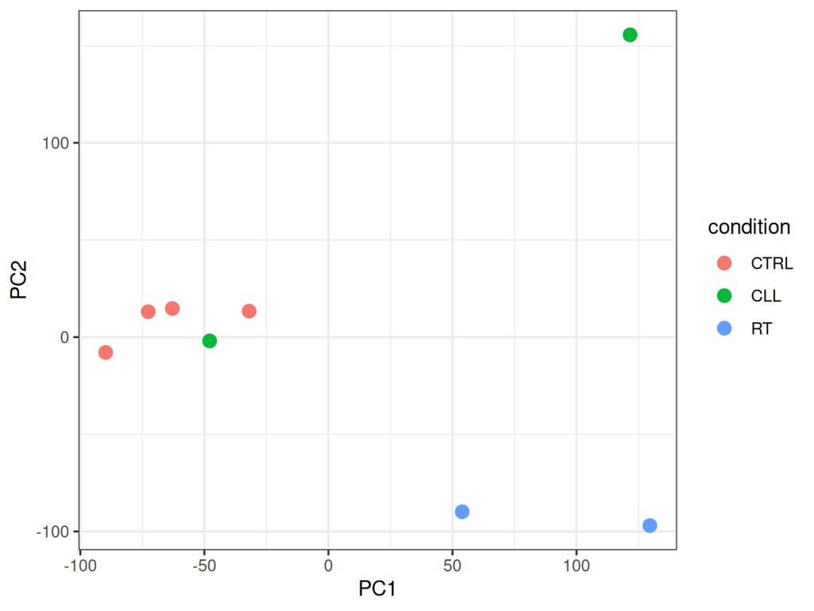

```r
# Variance stabilised transformation
vsdata <- vst(dds, blind = FALSE)

# Extract matrix
vs_mat <- assay(vsdata)

# Adjust for batch (assume batch info is in colData(dds)$batch)
vs_mat_corrected <- removeBatchEffect(vs_mat, batch = colData(dds)$batch)

# PCA on corrected data
pca <- prcomp(t(vs_mat_corrected))

# Make a dataframe for ggplot
pca_df <- data.frame(pca$x,
                     condition = colData(dds)$condition,
                     sample = rownames(colData(dds)))

# Plot
ggplot(pca_df, aes(PC1, PC2, color = condition)) +
  geom_point(size = 3) +
  theme_bw()
```

### Differential gene expression analysis

```r
# Generate a table for gene expression

# RT vs CTRL
res_RT_vs_CTRL <- lfcShrink(dds, contrast = c("condition", "RT", "CTRL"), type = "normal")

# CLL vs CTRL
res_CLL_vs_CTRL <- lfcShrink(dds, contrast = c("condition", "CLL", "CTRL"), type = "normal")

# RT vs CLL
res_RT_vs_CLL <- lfcShrink(dds, contrast = c("condition", "RT", "CLL"), type = "normal")
```

```r
# See the results
head(res_RT_vs_CLL)
```

```
log2 fold change (MAP): condition RT vs CLL
Wald test p-value: condition RT vs CLL
DataFrame with 6 rows and 6 columns
                     baseMean log2FoldChange     lfcSE      stat    pvalue
                    <numeric>      <numeric> <numeric> <numeric> <numeric>
ENSMUSG00000000001 1502.77927      -0.322764  0.516067 -0.625405  0.531705
ENSMUSG00000000028  484.45731       1.694606  1.478696  1.138369  0.254966
ENSMUSG00000000037    2.98918      -2.803271  1.837038 -1.586089  0.112719
ENSMUSG00000000049    2.19864      -0.550307  1.720706 -0.292808  0.769669
ENSMUSG00000000056  410.07475       0.714175  1.463127  0.491667  0.622955
ENSMUSG00000000058   65.28799      -1.540991  1.292932 -1.262835  0.206648
                        padj
                   <numeric>
ENSMUSG00000000001  0.710073
ENSMUSG00000000028  0.470894
ENSMUSG00000000037        NA
ENSMUSG00000000049        NA
ENSMUSG00000000056  0.776414
ENSMUSG00000000058  0.414750
```

### Convert mouse to human ensemble ids

```r
# Get orthologs
path_to_ortholog <- str_c(path_to_ref_transcriptome, "/mouse_human_ortholog.txt")
orthologs <- read.csv(path_to_ortholog)
head(orthologs)
```

```
   Gene.stable.ID Gene.stable.ID.version Mouse.gene.stable.ID Mouse.gene.name
1 ENSG00000198888      ENSG00000198888.2   ENSMUSG00000064341          mt-Nd1
2 ENSG00000198763      ENSG00000198763.3   ENSMUSG00000064345          mt-Nd2
3 ENSG00000198804      ENSG00000198804.2   ENSMUSG00000064351          mt-Co1
4 ENSG00000198712      ENSG00000198712.1   ENSMUSG00000064354          mt-Co2
5 ENSG00000228253      ENSG00000228253.1   ENSMUSG00000064356         mt-Atp8
6 ENSG00000198899      ENSG00000198899.2   ENSMUSG00000064357         mt-Atp6
  Gene.name
1    MT-ND1
2    MT-ND2
3    MT-CO1
4    MT-CO2
5   MT-ATP8
6   MT-ATP6
```

```r
# Use left_join to convert mouse to human ensembl ids
human_res_RT_vs_CTRL <- as.data.frame(res_RT_vs_CTRL) %>%
  rownames_to_column("Mouse_Ensembl_ID") %>%
  left_join(orthologs, by = c("Mouse_Ensembl_ID" = "Mouse.gene.stable.ID"))

human_res_CLL_vs_CTRL <- as.data.frame(res_CLL_vs_CTRL) %>%
  rownames_to_column("Mouse_Ensembl_ID") %>%
  left_join(orthologs, by = c("Mouse_Ensembl_ID" = "Mouse.gene.stable.ID"))

human_res_RT_vs_CLL <- as.data.frame(res_RT_vs_CLL) %>%
  rownames_to_column("Mouse_Ensembl_ID") %>%
  left_join(orthologs, by = c("Mouse_Ensembl_ID" = "Mouse.gene.stable.ID"))
```

```r
# Save the expression result
saveRDS(human_res_RT_vs_CTRL, path_to_save_RT_vs_CRTL_dea)
saveRDS(human_res_CLL_vs_CTRL, path_to_save_CLL_vs_CRTL_dea)
saveRDS(human_res_RT_vs_CLL, path_to_save_RT_vs_CLL_dea)
```

### Plot heatmap of gene expression

```r
# Import the relevant package
library(pheatmap)
library(RColorBrewer)
```

```r
# Data transformation
vsd <- vst(dds, blind=FALSE)       # Variance-stabilizing transformation
#rld <- rlog(dds_filtered, blind=FALSE)      # Regularized log transformation

# Extract transformed expression matrix
expr_mat <- assay(vsd)

# Calculate z-scores
zscore_mat <- t(scale(t(expr_mat)))
```

```r
# Define samples in each condition
CTRL_sample <- colData$samples[colData$condition == "CTRL"]
CLL_sample <- colData$samples[colData$condition == "CLL"]
RT_sample <- colData$samples[colData$condition == "RT"]
```

#### CLL vs CTRL

```r
# Select only CLL vs CTRL
zscore_mat_CLL_vs_CTRL <- zscore_mat[, match(union(CTRL_sample, CLL_sample), colnames(zscore_mat))]
```

```r
# Change column names of the matrix
new_col_names <- str_c(
  colData$samples[match(colnames(zscore_mat_CLL_vs_CTRL), colData$samples)],
  "_",
  colData$condition[match(colnames(zscore_mat_CLL_vs_CTRL), colData$samples)]
  )
colnames(zscore_mat_CLL_vs_CTRL) <- new_col_names
```

```r
# Extract main and sub- clusters info from column names
conditions <-  ifelse(grepl("CTRL", colnames(zscore_mat_CLL_vs_CTRL)), "CTRL", "CLL")

# Create annotation dataframe
annotation_col <- data.frame(
  Condition = factor(conditions, levels = c("CTRL", "CLL"))
)
annotation_col <- annotation_col[, "Condition", drop = FALSE]  # keep as data frame
rownames(annotation_col) <- colnames(zscore_mat_CLL_vs_CTRL)

# Order by Condition and then Case
order_cols <- order(annotation_col$Condition)
zscore_mat_ordered <- zscore_mat_CLL_vs_CTRL[, order_cols]
annotation_col_ordered <- annotation_col[order_cols, , drop = FALSE]
```

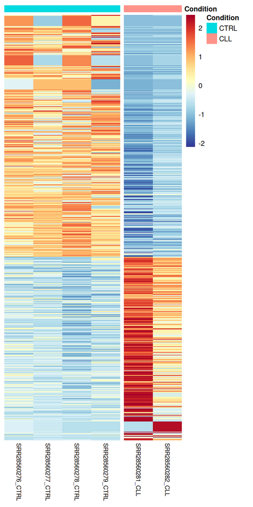

```r
# Filter for significant DE genes
sig_genes <- human_res_CLL_vs_CTRL[!is.na(human_res_CLL_vs_CTRL$padj) & human_res_CLL_vs_CTRL$padj < 0.05 & abs(human_res_CLL_vs_CTRL$log2FoldChange) > 1.5, ]

# Order genes by log2FoldChange (descending: up -> down)
gene_order <- sig_genes$Mouse_Ensembl_ID[order(sig_genes$log2FoldChange, decreasing = FALSE)]

# Subset zscore matrix
zscore_mat_sig <- zscore_mat_ordered[gene_order, ]

# Plot heatmap
pheatmap(
  zscore_mat_sig,
  cluster_rows = FALSE,
  cluster_cols = FALSE,
  show_rownames = FALSE,
  color = colorRampPalette(rev(brewer.pal(11, "RdYlBu")))(100),
  annotation_col = annotation_col_ordered,
  fontsize = 8,
  fontsize_row = 7,
  fontsize_col = 7,
  gaps_col = which(diff(as.numeric(factor(annotation_col_ordered$Condition))) != 0)
)
```

#### RT vs CTRL

```r
# Select only CLL vs CTRL
zscore_mat_RT_vs_CTRL <- zscore_mat[, match(union(CTRL_sample, RT_sample), colnames(zscore_mat))]
```

```r
# Change column names of the matrix
new_col_names <- str_c(
  colData$samples[match(colnames(zscore_mat_RT_vs_CTRL), colData$samples)],
  "_",
  colData$condition[match(colnames(zscore_mat_RT_vs_CTRL), colData$samples)]
  )
colnames(zscore_mat_RT_vs_CTRL) <- new_col_names
```

```r
# Extract main and sub- clusters info from column names
conditions <-  ifelse(grepl("CTRL", colnames(zscore_mat_RT_vs_CTRL)), "CTRL", "RT")

# Create annotation dataframe
annotation_col <- data.frame(
  Condition = factor(conditions, levels = c("CTRL", "RT"))
)
annotation_col <- annotation_col[, "Condition", drop = FALSE]  # keep as data frame
rownames(annotation_col) <- colnames(zscore_mat_RT_vs_CTRL)

# Order by Condition and then Case
order_cols <- order(annotation_col$Condition)
zscore_mat_ordered <- zscore_mat_RT_vs_CTRL[, order_cols]
annotation_col_ordered <- annotation_col[order_cols, , drop = FALSE]
```

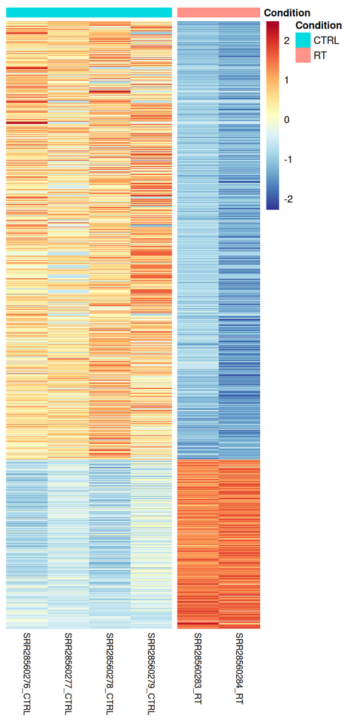

```r
# Filter for significant DE genes
sig_genes <- human_res_RT_vs_CTRL[!is.na(human_res_RT_vs_CTRL$padj) & human_res_RT_vs_CTRL$padj < 0.05 & abs(human_res_RT_vs_CTRL$log2FoldChange) > 1.5, ]

# Order genes by log2FoldChange (descending: up -> down)
gene_order <- sig_genes$Mouse_Ensembl_ID[order(sig_genes$log2FoldChange, decreasing = FALSE)]

# Subset zscore matrix
zscore_mat_sig <- zscore_mat_ordered[gene_order, ]

# Plot heatmap
pheatmap(
  zscore_mat_sig,
  cluster_rows = FALSE,
  cluster_cols = FALSE,
  show_rownames = FALSE,
  color = colorRampPalette(rev(brewer.pal(11, "RdYlBu")))(100),
  annotation_col = annotation_col_ordered,
  fontsize = 8,
  fontsize_row = 7,
  fontsize_col = 7,
  gaps_col = which(diff(as.numeric(factor(annotation_col_ordered$Condition))) != 0)
)
```

## Gene Set Enrichment Analysis (GSEA)

```r
# Import the related libraries in functional enrichment analysis
library(clusterProfiler)
library(enrichplot)
library(msigdbr)
library(org.Hs.eg.db)
```

### CLL vs CTRL

```r
# Manipulate the expression data
dea <- human_res_CLL_vs_CTRL[!is.na(human_res_CLL_vs_CTRL$Gene.stable.ID), ]
lfc_vector <- dea$log2FoldChange # Create a named vector ranked based on the log2 fold change
names(lfc_vector) <- dea$Gene.stable.ID
lfc_vector <- na.omit(lfc_vector) # Omit any NA values
lfc_vector <- sort(lfc_vector, decreasing = TRUE) # Sort the log2 fold change in descending order
lfc_vector <- lfc_vector[!duplicated(names(lfc_vector))]
```

```r
# Hallmark
HM_gsea <- HM_GSEA(lfc_vector, gene_ident = "ensembl_gene")
```

```r
# Collect the HM GSEA result
HM_GSEA.result <- HM_gsea@result
HM_GSEA_selected.result <- HM_GSEA.result %>%
  as_tibble() %>%
  dplyr::select(c(Description, NES, pvalue, p.adjust))

DT::datatable(HM_GSEA_selected.result, options = list(scrollX = TRUE))
```

|  | Description | NES | pvalue | p.adjust |
| --- | --- | --- | --- | --- |
| 1 | HALLMARK_MYC_TARGETS_V1 | 2.210384893526186 | 1.749388911531892e-11 | 8.746944557659459e-10 |
| 2 | HALLMARK_INFLAMMATORY_RESPONSE | -1.822616590431435 | 3.636722113435376e-07 | 9.091805283588439e-06 |
| 3 | HALLMARK_COMPLEMENT | -1.791955360658811 | 7.030605904997842e-07 | 1.065349342108533e-05 |
| 4 | HALLMARK_HEME_METABOLISM | -1.780518929714926 | 8.522794736868267e-07 | 1.065349342108533e-05 |
| 5 | HALLMARK_ESTROGEN_RESPONSE_LATE | -1.769132645479199 | 1.776348152623573e-06 | 1.776348152623573e-05 |
| 6 | HALLMARK_COAGULATION | -1.853290197203123 | 2.573189018230635e-06 | 2.113804926268555e-05 |
| 7 | HALLMARK_EPITHELIAL_MESENCHYMAL_TRANSITION | -1.750544254103761 | 2.959326896775977e-06 | 2.113804926268555e-05 |
| 8 | HALLMARK_MYC_TARGETS_V2 | 2.111846817120047 | 7.70838922217028e-06 | 4.817743263856425e-05 |
| 9 | HALLMARK_KRAS_SIGNALING_UP | -1.671885850062522 | 2.277077645134296e-05 | 0.000126504313618572 |
| 10 | HALLMARK_ALLOGRAFT_REJECTION | -1.62671512962895 | 8.038562754660441e-05 | 0.0004019281377330221 |

[output cut: 16 more lines]

### RT vs CTRL

```r
# Manipulate the expression data
dea <- human_res_RT_vs_CTRL[!is.na(human_res_RT_vs_CTRL$Gene.stable.ID), ]
lfc_vector <- dea$log2FoldChange # Create a named vector ranked based on the log2 fold change
names(lfc_vector) <- dea$Gene.stable.ID
lfc_vector <- na.omit(lfc_vector) # Omit any NA values
lfc_vector <- sort(lfc_vector, decreasing = TRUE) # Sort the log2 fold change in descending order
lfc_vector <- lfc_vector[!duplicated(names(lfc_vector))]
```

```r
# Hallmark
HM_gsea <- HM_GSEA(lfc_vector, gene_ident = "ensembl_gene")
```

```r
# Collect the HM GSEA result
HM_GSEA.result <- HM_gsea@result
HM_GSEA_selected.result <- HM_GSEA.result %>%
  as_tibble() %>%
  dplyr::select(c(Description, NES, pvalue, p.adjust))

DT::datatable(HM_GSEA_selected.result, options = list(scrollX = TRUE))
```

|  | Description | NES | pvalue | p.adjust |
| --- | --- | --- | --- | --- |
| 1 | HALLMARK_TNFA_SIGNALING_VIA_NFKB | -2.108401672821057 | 4.595022814043455e-22 | 1.975859810038686e-20 |
| 2 | HALLMARK_MYC_TARGETS_V2 | 3.236885127916249 | 5.777316686607368e-19 | 1.242123087620584e-17 |
| 3 | HALLMARK_INFLAMMATORY_RESPONSE | -2.020145003961408 | 2.4247833535399e-17 | 3.475522806740523e-16 |
| 4 | HALLMARK_INTERFERON_GAMMA_RESPONSE | -1.968769755490851 | 1.727308126343092e-16 | 1.856856235818824e-15 |
| 5 | HALLMARK_ALLOGRAFT_REJECTION | -1.888724374364618 | 3.469982058587851e-13 | 2.984184570385552e-12 |
| 6 | HALLMARK_EPITHELIAL_MESENCHYMAL_TRANSITION | -1.860181308659735 | 7.50588180824344e-13 | 5.379215295907799e-12 |
| 7 | HALLMARK_IL2_STAT5_SIGNALING | -1.790156023102279 | 1.071075086575348e-10 | 6.579461246105709e-10 |
| 8 | HALLMARK_KRAS_SIGNALING_UP | -1.786746691536285 | 1.25045117544094e-10 | 6.721175067995052e-10 |
| 9 | HALLMARK_COMPLEMENT | -1.787522683527522 | 1.798210705399819e-10 | 8.591451148021358e-10 |
| 10 | HALLMARK_IL6_JAK_STAT3_SIGNALING | -1.978221822059306 | 1.706326326310519e-09 | 7.33720320313523e-09 |

[output cut: 13 more lines]

Our results for both CLL vs CTRL and RT vs CRTL were consistent with the original article in Figure 2B.

### RT vs CLL

```r
# Manipulate the expression data
dea <- human_res_RT_vs_CLL[!is.na(human_res_RT_vs_CLL$Gene.stable.ID), ]
lfc_vector <- dea$log2FoldChange # Create a named vector ranked based on the log2 fold change
names(lfc_vector) <- dea$Gene.stable.ID
lfc_vector <- na.omit(lfc_vector) # Omit any NA values
lfc_vector <- sort(lfc_vector, decreasing = TRUE) # Sort the log2 fold change in descending order
lfc_vector <- lfc_vector[!duplicated(names(lfc_vector))]
```

#### Hallmark

```r
# Hallmark
HM_gsea <- HM_GSEA(lfc_vector, gene_ident = "ensembl_gene")
```

```r
# Collect the HM GSEA result
HM_GSEA.result <- HM_gsea@result
HM_GSEA_selected.result <- HM_GSEA.result %>%
  as_tibble() %>%
  dplyr::select(c(Description, NES, pvalue, p.adjust))

DT::datatable(HM_GSEA_selected.result, options = list(scrollX = TRUE))
```

|  | Description | NES | pvalue | p.adjust |
| --- | --- | --- | --- | --- |
| 1 | HALLMARK_E2F_TARGETS | 3.471045530128191 | 3.998250794696459e-40 | 1.99912539734823e-38 |
| 2 | HALLMARK_MYC_TARGETS_V1 | 3.408558905075323 | 9.264275299563717e-37 | 2.316068824890929e-35 |
| 3 | HALLMARK_G2M_CHECKPOINT | 2.965568094212645 | 4.190209525525863e-25 | 6.983682542543106e-24 |
| 4 | HALLMARK_OXIDATIVE_PHOSPHORYLATION | 2.586781570596888 | 5.603160377666929e-18 | 7.003950472083661e-17 |
| 5 | HALLMARK_TNFA_SIGNALING_VIA_NFKB | -2.278821137528386 | 1.380544248506747e-17 | 1.380544248506747e-16 |
| 6 | HALLMARK_INTERFERON_GAMMA_RESPONSE | -2.18031252404449 | 3.660297662887986e-14 | 3.050248052406655e-13 |
| 7 | HALLMARK_INFLAMMATORY_RESPONSE | -2.130308664863605 | 3.165240369942479e-13 | 2.260885978530342e-12 |
| 8 | HALLMARK_IL2_STAT5_SIGNALING | -1.955212744608066 | 1.378388259145766e-09 | 8.614926619661037e-09 |
| 9 | HALLMARK_ALLOGRAFT_REJECTION | -1.956230461589125 | 3.259200100670052e-09 | 1.810666722594473e-08 |
| 10 | HALLMARK_EPITHELIAL_MESENCHYMAL_TRANSITION | -1.877269960069527 | 5.245253328129288e-08 | 2.622626664064644e-07 |

[output cut: 16 more lines]

We will explore the trends of hallmark terms reported from other single-cell pseudobulk studies such as Nadeu et al. (2022) and Hing et al (2023). From those studies, the terms such as E2F targets, Myc targets, and oxidative phosphorylation (OXPHOS) were upregulated.

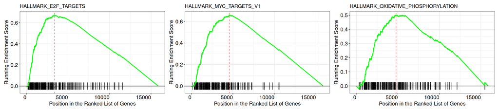

```r
# GSEA plot for HALLMARK_E2F_TARGETS, HALLMARK_MYC_TARGETS_V1, and HALLMARK_OXIDATIVE_PHOSPHORYLATION

E2F_gsea.plt <- gseaplot(HM_gsea,
                          by = "runningScore",
                          title = "HALLMARK_E2F_TARGETS",
                          geneSetID = "HALLMARK_E2F_TARGETS",
                          base_size = 10) +
  theme(axis.text.x = element_text(angle = 0, hjust = 1))

Myc_gsea.plt <- gseaplot(HM_gsea,
                          by = "runningScore",
                          title = "HALLMARK_MYC_TARGETS_V1",
                          geneSetID = "HALLMARK_MYC_TARGETS_V1",
                          base_size = 10) +
  theme(axis.text.x = element_text(angle = 0, hjust = 1))

OXPHOS_gsea.plt <- gseaplot(HM_gsea,
                          by = "runningScore",
                          title = "HALLMARK_OXIDATIVE_PHOSPHORYLATION",
                          geneSetID = "HALLMARK_OXIDATIVE_PHOSPHORYLATION",
                          base_size = 10) +
  theme(axis.text.x = element_text(angle = 0, hjust = 1))

E2F_gsea.plt + Myc_gsea.plt + OXPHOS_gsea.plt
```

#### GO:BP

```r
# GO:BP
GOBP_gsea <- GO_GSEA(lfc_vector, gene_ident = "ensembl_gene")
```

```r
# Collect the GSEA result
GOBP_GSEA.result <- GOBP_gsea@result
GOBP_GSEA_selected.result <- GOBP_GSEA.result %>%
  as_tibble() %>%
  dplyr::select(c(Description, NES, pvalue, p.adjust))

DT::datatable(GOBP_GSEA_selected.result, options = list(scrollX = TRUE))
```

|  | Description | NES | pvalue | p.adjust |
| --- | --- | --- | --- | --- |
| 1 | GOBP_RIBONUCLEOPROTEIN_COMPLEX_BIOGENESIS | 2.594606657147786 | 7.084959328782525e-32 | 1.990873571387889e-28 |
| 2 | GOBP_RIBOSOME_BIOGENESIS | 2.561566371221135 | 1.772815767945651e-24 | 2.49080615396364e-21 |
| 3 | GOBP_RRNA_PROCESSING | 2.69159743873485 | 2.05921998468514e-20 | 1.928802718988414e-17 |
| 4 | GOBP_RRNA_METABOLIC_PROCESS | 2.413653752198025 | 1.867093074607502e-18 | 1.31163288491177e-15 |
| 5 | GOBP_IMMUNE_RESPONSE_REGULATING_CELL_SURFACE_RECEPTOR_SIGNALING_PATHWAY | -2.064102111003326 | 6.57962053395147e-16 | 3.697746740080726e-13 |
| 6 | GOBP_IMMUNE_RESPONSE_REGULATING_SIGNALING_PATHWAY | -1.873575791673762 | 2.525897899718007e-15 | 1.1829621830346e-12 |
| 7 | GOBP_POSITIVE_REGULATION_OF_CYTOKINE_PRODUCTION | -1.886616945069175 | 5.566326645523344e-14 | 2.234482553417228e-11 |
| 8 | GOBP_ALPHA_BETA_T_CELL_ACTIVATION | -2.194961677759382 | 7.727733724283956e-14 | 2.71436647065474e-11 |
| 9 | GOBP_MITOCHONDRIAL_TRANSLATION | 2.556456438568271 | 1.349688403025685e-13 | 4.214027125002416e-11 |
| 10 | GOBP_RNA_SPLICING_VIA_TRANSESTERIFICATION_REACTIONS | 2.061639601098131 | 3.844915593349076e-13 | 1.08042128173109e-10 |

[output cut: 683 more lines]

We will also explore the trends of GO:BP terms reported from other single-cell studies such as Nadeu et al. (2022) and Hing et al (2023). From those studies, the terms such as OXPHOS and mitochondrial translation were upregulated while BCR signalling was downregulated.

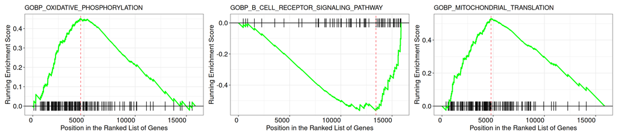

```r
# GSEA plot for GOBP_OXIDATIVE_PHOSPHORYLATION, GOBP_B_CELL_RECEPTOR_SIGNALING_PATHWAY, and GOBP_MITOCHONDRIAL_TRANSLATION

OXPHOS_GO_gsea.plt <- gseaplot(GOBP_gsea,
                          by = "runningScore",
                          title = "GOBP_OXIDATIVE_PHOSPHORYLATION",
                          geneSetID = "GOBP_OXIDATIVE_PHOSPHORYLATION",
                          base_size = 10) +
  theme(axis.text.x = element_text(angle = 0, hjust = 1))

BCR_GO_gsea.plt <- gseaplot(GOBP_gsea,
                          by = "runningScore",
                          title = "GOBP_B_CELL_RECEPTOR_SIGNALING_PATHWAY",
                          geneSetID = "GOBP_B_CELL_RECEPTOR_SIGNALING_PATHWAY",
                          base_size = 10) +
  theme(axis.text.x = element_text(angle = 0, hjust = 1))

mitochondrial_GO_gsea.plt <- gseaplot(GOBP_gsea,
                          by = "runningScore",
                          title = "GOBP_MITOCHONDRIAL_TRANSLATION",
                          geneSetID = "GOBP_MITOCHONDRIAL_TRANSLATION",
                          base_size = 10) +
  theme(axis.text.x = element_text(angle = 0, hjust = 1))

OXPHOS_GO_gsea.plt + BCR_GO_gsea.plt + mitochondrial_GO_gsea.plt
```

```r
# Save gene expression and GSEA data
saveRDS(HM_gsea, path_to_save_hm_gsea)
saveRDS(GOBP_gsea, path_to_save_go_gsea)
```